# Reaction time pre-processing: effect size estimate and overview on pipelines used

Hannah Loenneker

18 12 2022

```r
library(tidyverse)
library(gmodels)
library(metafor)
library(data.table)
library(psych)
```

# Read in datasets

#### Study inclusion

```r
dat_incl <- fread(here::here("data",
                     "Literatur_screening_coders1_2.txt"))
```

#### Codebook for data extraction

```r
codebook <- read.table(here::here("data",
                        "Literatur_coding_sheet_codebook.txt"),
                 header = T, sep = "\t", dec = ".")
```

#### Dataset with extracted values for further analyses & creating necessary variables

```r
dat_all <- read.table(here::here("data", "Literatur_coding_sheet_2022_12_04.txt"),
                header = T, sep = "\t", dec = ".")
```

```r
# Merge pipelines

dat_all <- dat_all %>%
    unite(
        "pipelines_all",
        Preprocessing1_correct_answers_only,
        Preprocessing2_exclusion_missing_data,
        Preprocessing3_exclusion_fillers,
        Preprocessing4_exclusion_participants,
        Preprocessing5_exclusion_trials,
        Preprocessing6a_trim_fixed_minimum,
        Preprocessing6b_trim_fixed_min_value,
        Preprocessing7a_trim_fixed_maximum,
        Preprocessing7b_trim_fixed_max_value,
        Preprocessing8a_trim_data_driven_type,
        Preprocessing8b_trim_data_driven_value,
        Preprocessing9_transformation,
        Preprocessing10_robust_stat,
        Preprocessing11_assumption_check,
        Preprocessing12._multiple.comparison.correction,
        remove = F
    ) %>%
    unite(
        "Preprocessing6",
        Preprocessing6a_trim_fixed_minimum,
        Preprocessing6b_trim_fixed_min_value,
        remove = F
    ) %>%
    unite(
        "Preprocessing7",
        Preprocessing7a_trim_fixed_maximum,
        Preprocessing7b_trim_fixed_max_value,
        remove = F
    ) %>%
    unite("Preprocessing6_7",
        Preprocessing6,
        Preprocessing7,
        remove = F) %>%
    unite(
        "Preprocessing8",
        Preprocessing8a_trim_data_driven_type,
        Preprocessing8b_trim_data_driven_value,
        remove = F
    )

# Variables to check if data is complete for meta-analysis
dat_all <- dat_all %>%
    dplyr::mutate(mean_complete = ifelse(Mean1 >= 1 &
                                Mean2 >= 1 | Diff_cond1_cond2_mean >= abs(1), 1, 0))   %>%
    dplyr::mutate(sd_complete = ifelse(SD1 >= 1 &
                                SD2 >= 1 | Diff_cond1_cond2_SD >= 1, 1, 0)) %>%
    dplyr::mutate(N_complete = ifelse(N_within_groups >= 1, 1, 0)) %>%
    dplyr::mutate(N_trials = ifelse(N_repeated_measurements >= 1, 1, 0))
# Summary variables for preprocessing steps
dat_all <- dat_all %>%
    dplyr::mutate(prep1 = ifelse(Preprocessing1_correct_answers_only == 1, 1, 0)) %>%
    dplyr::mutate(
        prep2 = ifelse(
            Preprocessing2_exclusion_missing_data == 1 |
                Preprocessing2_exclusion_missing_data == 2 |
                Preprocessing2_exclusion_missing_data == 3,
            1,
            0
        )
    ) %>%
    dplyr::mutate(prep3 = ifelse(Preprocessing3_exclusion_fillers == 1, 1, 0)) %>%
    dplyr::mutate(
        prep4 = ifelse(
            Preprocessing4_exclusion_participants == 1 |
                Preprocessing4_exclusion_participants == 2,
            1,
            0
        )
    ) %>%
    dplyr::mutate(prep5 = ifelse(Preprocessing5_exclusion_trials == 1, 1, 0)) %>%
    dplyr::mutate(prep6 = ifelse(Preprocessing6a_trim_fixed_minimum == 1, 1, 0)) %>%
    dplyr::mutate(prep7 = ifelse(Preprocessing7a_trim_fixed_maximum == 1, 1, 0)) %>%
    dplyr::mutate(
        prep8 = ifelse(
            Preprocessing8a_trim_data_driven_type == 0 |
                Preprocessing8a_trim_data_driven_type == 13,
            0,
            1
        )
    ) %>%
    dplyr::mutate(prep9 = ifelse(
        Preprocessing9_transformation == 0 |
            Preprocessing9_transformation == 4,
        0,
        1
    )) %>%
    dplyr::mutate(prep_sum = prep1 + prep2 + prep3 + prep4 + prep5 + prep6 + prep7 + prep8 + prep9)
# Summary variables for reporting proportion of excluded observations and excluded participants
dat_all <- dat_all %>%
    dplyr::mutate(outlier_sum = ifelse(Outliers_eliminated >= 0.01, 1, 0))
dat_all <- dat_all %>%
    dplyr::mutate(participant_sum = ifelse(Preprocessing4_number_excluded >= 0, 1, 0))
# Variables for reporting the reason for preprocessing choice
dat_all <- dat_all %>%
    dplyr::mutate(ratio1 = ifelse(Rationale1 != "NA", 1, 0)) %>%
    dplyr::mutate(ratio2 = ifelse(Rationale2 != "NA", 1, 0)) %>%
    dplyr::mutate(ratio3 = ifelse(Rationale3 != "NA", 1, 0)) %>%
    dplyr::mutate(ratio4 = ifelse(Rationale4 != "NA", 1, 0)) %>%
    dplyr::mutate(ratio5 = ifelse(Rationale5 != "NA", 1, 0)) %>%
    dplyr::mutate(ratio6a = ifelse(Rationale6a != "NA", 1, 0)) %>%
    dplyr::mutate(ratio6b = ifelse(Rationale6b != "NA", 1, 0)) %>%
    dplyr::mutate(ratio7a = ifelse(Rationale7a != "NA", 1, 0)) %>%
    dplyr::mutate(ratio7b = ifelse(Rationale7b != "NA", 1, 0)) %>%
    dplyr::mutate(ratio8a = ifelse(Rationale7a != "NA", 1, 0)) %>%
    dplyr::mutate(ratio8b = ifelse(Rationale7b != "NA", 1, 0)) %>%
    dplyr::mutate(ratio9 = ifelse(Rationale9 != "NA", 1, 0))
dat_all <- dat_all %>%
    dplyr::mutate(
        rationale_sum = ifelse(
            Rationale1 != "NA" |
                Rationale2 != "NA" |
                Rationale3 != "NA" |
                Rationale4 != "NA" |
                Rationale5 != "NA" |
                Rationale6a != "NA" |
                Rationale6b != "NA" |
                Rationale7a != "NA" |
                Rationale7b != "NA" |
                Rationale8a != "NA" |
                Rationale8b != "NA" |
                Rationale9 != "NA",
            1,
            0
        )
    )
# Summary variables for order of preprocessing steps
dat_all <- dat_all %>%
    dplyr::mutate(
        order_sum = ifelse(
            Preprocessing1_order >= 1 &
                Preprocessing2_order >= 1 |
                Preprocessing3_order >= 1 |
                Preprocessing4_order >= 1 |
                Preprocessing5_order >= 1 |
                Preprocessing6_order >= 1 |
                Preprocessing7_order >= 1 |
                Preprocessing8_order >= 1 |
                Preprocessing9_order >= 1,
            1,
            0
        )
    )

# Calculating effect sizes and their variance:
dat_all <- dat_all %>%
    dplyr::mutate(d =
                (Mean2 - Mean1) / (sqrt((((SD2 ^ 2) * (N2 - 1)
                ) + ((SD1 ^ 2) * (N1 - 1)
                )) / (N1 + N2 - 2)))) %>%
    dplyr::mutate(d_diff =
                Diff_cond1_cond2_mean / Diff_cond1_cond2_SD) %>%
    dplyr::mutate(es = coalesce(d, d_diff)) %>%
    dplyr::mutate(es_var =
                (1 / N2) + (1 / N1) + ((es ^ 2) / (2 * (N2 + N1))))
```

### Summary of included studies and inter-rater reliability

```r
initial_n <-
    length(dat_incl$ID) # number of studies included in the screening process
dat_incl_no_dupl <- dat_incl %>%
    filter(!grepl('duplicate', Reason_final))
sum_coders1 <-
    sum(dat_incl_no_dupl$Inclusion_1) # number of studies included by first group of coders
sum_coders2 <-
    sum(dat_incl_no_dupl$Inclusion_2) # number of studies included by second group of coders
dat_kappa <- dat_incl_no_dupl %>%
    select(Inclusion_1, Inclusion_2) %>%
    as.data.frame(dat_kappa)
res.k <- psych::cohen.kappa(dat_kappa, alpha = 0.05)
res.k # inter-rater reliability
```

```
## Call: cohen.kappa1(x = x, w = w, n.obs = n.obs, alpha = alpha, levels = levels)
##
## Cohen Kappa and Weighted Kappa correlation coefficients and confidence boundaries
##                  lower estimate upper
## unweighted kappa  0.87     0.93  0.98
## weighted kappa    0.87     0.93  0.98
##
##  Number of subjects = 334
```

```r
sum_final <-
    gmodels::CrossTable(dat_incl_no_dupl$Reason_final,
                  dat_incl_no_dupl$Inclusion_final)
```

```
##
##
##    Cell Contents
## |-------------------------|
## |                       N |
## | Chi-square contribution |
## |           N / Row Total |
## |           N / Col Total |
## |         N / Table Total |
## |-------------------------|
##
##
## Total Observations in Table:  334
##
##
##                                        | dat_incl_no_dupl$Inclusion_final
##          dat_incl_no_dupl$Reason_final |         0 |         1 | Row Total |
## ---------------------------------------|-----------|-----------|-----------|
##                                        |         0 |        55 |        55 |
##                                        |    45.943 |   233.057 |           |
##                                        |     0.000 |     1.000 |     0.165 |
##                                        |     0.000 |     1.000 |           |
##                                        |     0.000 |     0.165 |           |
## ---------------------------------------|-----------|-----------|-----------|
##                   Accessory Simon task |         3 |         0 |         3 |
##                                        |     0.097 |     0.494 |           |
##                                        |     1.000 |     0.000 |     0.009 |
##                                        |     0.011 |     0.000 |           |
##                                        |     0.009 |     0.000 |           |
## ---------------------------------------|-----------|-----------|-----------|
##                   Affective Simon task |         7 |         0 |         7 |
##                                        |     0.227 |     1.153 |           |
##                                        |     1.000 |     0.000 |     0.021 |
##                                        |     0.025 |     0.000 |           |
##                                        |     0.021 |     0.000 |           |
## ---------------------------------------|-----------|-----------|-----------|
##         Affective Simon task, vertical |         1 |         0 |         1 |
##                                        |     0.032 |     0.165 |           |
##                                        |     1.000 |     0.000 |     0.003 |
##                                        |     0.004 |     0.000 |           |
```

[output cut: 148 more lines]

```
##                                        |     1.000 |     0.000 |     0.003 |
##                                        |     0.004 |     0.000 |           |
##                                        |     0.003 |     0.000 |           |
## ---------------------------------------|-----------|-----------|-----------|
##                          Vertical task |        11 |         0 |        11 |
##                                        |     0.357 |     1.811 |           |
##                                        |     1.000 |     0.000 |     0.033 |
##                                        |     0.039 |     0.000 |           |
##                                        |     0.033 |     0.000 |           |
## ---------------------------------------|-----------|-----------|-----------|
##                           Column Total |       279 |        55 |       334 |
##                                        |     0.835 |     0.165 |           |
## ---------------------------------------|-----------|-----------|-----------|
##
##
```

```r
# number of articles excluded per reason
table(dat_all$Article) # overview of observations included per article
```

```
##
##        W\xfchr_2005      Aisenberg_2012 Mittelst\xe4dt_2018      Aisenberg_2014
##                   3                   3                   2                   5
##      Aisenberg_2015        Bashore_2018          Burle_2002          Burle_2005
##                   1                   2                   1                   2
##            Cho_2011          Craft_1970          Crump_2013       Davidson_2006
##                   8                   2                   1                   1
##        W\xfchr_2006      Davranche_2020         Dommes_2015      Hasbroucq_2009
##                   4                   1                   1                   1
##       Hasbroucq1991          Hedge_1975        Heister_1994       Hietanen_1995
##                   1                   1                   2                   1
##       Hoffmann_2014          Jones_2016    Kalanthroff_2020          Kotov_2017
##                   1                   1                   1                   4
##      KuboKawai_2010         LevAri_2014         Masaki_2000       McIntosh_2017
##                   1                   1                   1                   1
##          Miles_2012         Miller_2016          Mosso_2020          Neveu_2016
##                   2                   1                   1                   1
##         Oleary_1993       Peterson_2002          Ragot_1981          Ragot_1984
##                   2                   1                   1                   2
##          Ragot_1986        Ramdani_2013       Schnabel_2021      Schneider_2020
##                   4                   1                   1                   2
##          Simon_1981          Simon_1990         Stocco_2017      Tagliabue_2007
##                   2                   1                   1                   3
##           Toth_1995         Umilta_1999    ValleInclan_1996    ValleInclan_2003
##                   3                   5                   1                   1
##        VanVeen_2008        Wallace_1971        Wallace_1972          Zhang_2004
##                   2                   2                   2                  10
##           Zhou_2020          Zwaan_2018        W\xfchr_2018
##                   1                   4                   4
```

### Analysis of extracted data

#### Preprocessing pipelines

aggregate dataset to pipeline per article

```r
dat_pipe <- dat_all[!duplicated(dat_all$Article), ]
```

##### Summary of pipeline frequencies

72.7% of studies reported that they only included correct answers in their RT analysis.

```r
CrossTable(dat_pipe$Preprocessing1_correct_answers_only)
```

```
##
##
##    Cell Contents
## |-------------------------|
## |                       N |
## |         N / Table Total |
## |-------------------------|
##
##
## Total Observations in Table:  55
##
##
##           |         0 |         1 |         3 |
##           |-----------|-----------|-----------|
##           |         3 |        40 |        12 |
##           |     0.055 |     0.727 |     0.218 |
##           |-----------|-----------|-----------|
##
##
##
##
```

```r
# 0 = no exclusion of errors, 1 = inclusion of correct trials only, 2 = not mentioned
```

1.8% of articles excluded missing data case-wise, none excluded missing data list-wise and 3.6% used multiple imputations.

```r
CrossTable(dat_pipe$Preprocessing2_exclusion_missing_data)
```

```
##
##
##    Cell Contents
## |-------------------------|
## |                       N |
## |         N / Table Total |
## |-------------------------|
##
##
## Total Observations in Table:  55
##
##
##           |         0 |         1 |         3 |         4 |
##           |-----------|-----------|-----------|-----------|
##           |         1 |         1 |         2 |        51 |
##           |     0.018 |     0.018 |     0.036 |     0.927 |
##           |-----------|-----------|-----------|-----------|
##
##
##
##
```

```r
# 0 = no data excluded, 1 = case-wise, 2 = list-wise, 3 = multiple imputation, 4 = not mentioned
```

7.3% reported that they excluded fillers, while 63.6% did not have fillers in their experimental design.

```r
CrossTable(dat_pipe$Preprocessing3_exclusion_fillers)
```

```
##
##
##    Cell Contents
## |-------------------------|
## |                       N |
## |         N / Table Total |
## |-------------------------|
##
##
## Total Observations in Table:  55
##
##
##           |         0 |         1 |         2 |         3 |
##           |-----------|-----------|-----------|-----------|
##           |         4 |         4 |        35 |        12 |
##           |     0.073 |     0.073 |     0.636 |     0.218 |
##           |-----------|-----------|-----------|-----------|
##
##
##
##
```

```r
# 0 = no fillers excluded,  1 = fillers excluded, 2 = no fillers in experimental design, 3 = not mentioned
```

25.5% excluded participants case-wise and 1.8% list-wise for different quality or theoretical reasons (e.g., low accuracy rates on the Simon task of < 50%, < 75%, < 80%, or < 85%, mean reaction time larger than 2, 3 or 4 SD of the group mean, inability to attain a learning criteria within the experimental paradigm, left-handers, technical errors). One study even mentioned that the participant exclusion followed a pre-registered criterion.

```r
CrossTable(dat_pipe$Preprocessing4_exclusion_participants)
```

```
##
##
##    Cell Contents
## |-------------------------|
## |                       N |
## |         N / Table Total |
## |-------------------------|
##
##
## Total Observations in Table:  55
##
##
##           |         0 |         1 |         2 |         3 |
##           |-----------|-----------|-----------|-----------|
##           |         2 |        14 |         1 |        38 |
##           |     0.036 |     0.255 |     0.018 |     0.691 |
##           |-----------|-----------|-----------|-----------|
##
##
##
##
```

```r
# 0 = no exclusion, 1 = case-wise, 2 = list-wise, 3 = not mentioned
table(dat_pipe$Rationale4)
```

[output not shown]

[output cut: 19 more lines]

In 18.2% of articles, single trials were also excluded for quality reasons (e.g., simultaneous events within the same 10 ms interval, low accuracy) or because they were classified as practice.

```r
CrossTable(dat_pipe$Preprocessing5_exclusion_trials)
```

```
##
##
##    Cell Contents
## |-------------------------|
## |                       N |
## |         N / Table Total |
## |-------------------------|
##
##
## Total Observations in Table:  55
##
##
##           |         0 |         1 |         3 |
##           |-----------|-----------|-----------|
##           |         1 |        10 |        44 |
##           |     0.018 |     0.182 |     0.800 |
##           |-----------|-----------|-----------|
##
##
##
##
```

```r
# 0 = no exclusion, 1 = trials excluded, 3 = not mentioned
table(dat_pipe$Rationale5)
```

```
##
## Because of tonic activity, 245 trials (0.89%) were rejected. In addition, simultaneous events (within the same 10-ms interval) occurred in 681 trials (2.46%) and were rejected.
##                                                                                                                                                                                1
##                                                                                                                                                         due to very low accuracy
##                                                                                                                                                                                1
##                                                                                                                      exclusion of block 1 and 2 entirely because of too slow RTs
##                                                                                                                                                                                1
##                                                                                                                                                                         outliers
##                                                                                                                                                                                1
##                                                             related to the electrophysiological recordings: removed trials occuring during the eye movements and other artefacts
##                                                                                                                                                                                1
##                                                                          The first block of trials was discarded as practice, as were the first four rin-in trials of each block
##                                                                                                                                                                                1
##                                                                                    The first block of trials, and the first trial of each block were excluded from the analysis.
##                                                                                                                                                                                1
##                                                                                               the first trial in each block was not analysed because it had no predecessor trial
##                                                                                                                                                                                1
```

```r
CrossTable(dat_pipe$Preprocessing6)
```

```
##
##
##    Cell Contents
## |-------------------------|
## |                       N |
## |         N / Table Total |
## |-------------------------|
##
##
## Total Observations in Table:  55
##
##
##           |      0_NA |     1_100 |     1_130 |     1_150 |     1_200 |
##           |-----------|-----------|-----------|-----------|-----------|
##           |         7 |         7 |         1 |         5 |         5 |
##           |     0.127 |     0.127 |     0.018 |     0.091 |     0.091 |
##           |-----------|-----------|-----------|-----------|-----------|
##
##
##           |     1_300 |      2_NA |
##           |-----------|-----------|
##           |         1 |        29 |
##           |     0.018 |     0.527 |
##           |-----------|-----------|
##
##
##
##
```

```r
CrossTable(dat_pipe$Preprocessing7)
```

```
##
##
##    Cell Contents
## |-------------------------|
## |                       N |
## |         N / Table Total |
## |-------------------------|
##
##
## Total Observations in Table:  55
##
##
##           |      0_NA |    1_1000 |    1_1200 |    1_1500 |    1_2000 |
##           |-----------|-----------|-----------|-----------|-----------|
##           |         4 |         3 |         1 |         7 |         2 |
##           |     0.073 |     0.055 |     0.018 |     0.127 |     0.036 |
##           |-----------|-----------|-----------|-----------|-----------|
##
##
##           |     1_500 |     1_600 |     1_800 |     1_815 |     1_900 |
##           |-----------|-----------|-----------|-----------|-----------|
##           |         1 |         1 |         4 |         1 |         1 |
##           |     0.018 |     0.018 |     0.073 |     0.018 |     0.018 |
##           |-----------|-----------|-----------|-----------|-----------|
##
##
##           |      2_NA |
##           |-----------|
##           |        30 |
##           |     0.545 |
##           |-----------|
##
##
##
##
```

```r
CrossTable(dat_pipe$Preprocessing6_7)
```

```
##
##
##    Cell Contents
## |-------------------------|
## |                       N |
## |         N / Table Total |
## |-------------------------|
##
##
## Total Observations in Table:  55
##
##
##              |    0_NA_0_NA |  0_NA_1_1200 |  0_NA_1_1500 |  0_NA_1_2000 |   1_100_0_NA |
##              |--------------|--------------|--------------|--------------|--------------|
##              |            3 |            1 |            2 |            1 |            1 |
##              |        0.055 |        0.018 |        0.036 |        0.018 |        0.018 |
##              |--------------|--------------|--------------|--------------|--------------|
##
##
##              | 1_100_1_1000 | 1_100_1_1500 |  1_100_1_800 |  1_100_1_900 |   1_100_2_NA |
##              |--------------|--------------|--------------|--------------|--------------|
##              |            1 |            1 |            2 |            1 |            1 |
##              |        0.018 |        0.018 |        0.036 |        0.018 |        0.018 |
##              |--------------|--------------|--------------|--------------|--------------|
##
##
##              |  1_130_1_815 | 1_150_1_1000 | 1_150_1_1500 |  1_150_1_800 |   1_150_2_NA |
##              |--------------|--------------|--------------|--------------|--------------|
##              |            1 |            1 |            1 |            2 |            1 |
##              |        0.018 |        0.018 |        0.018 |        0.036 |        0.018 |
##              |--------------|--------------|--------------|--------------|--------------|
##
##
##              | 1_200_1_1000 | 1_200_1_1500 |  1_200_1_600 |   1_200_2_NA | 1_300_1_1500 |
##              |--------------|--------------|--------------|--------------|--------------|
##              |            1 |            1 |            1 |            2 |            1 |
##              |        0.018 |        0.018 |        0.018 |        0.036 |        0.018 |
##              |--------------|--------------|--------------|--------------|--------------|
##
##
##              |  2_NA_1_1500 |  2_NA_1_2000 |   2_NA_1_500 |    2_NA_2_NA |
##              |--------------|--------------|--------------|--------------|
##              |            1 |            1 |            1 |           26 |
##              |        0.018 |        0.018 |        0.018 |        0.473 |
##              |--------------|--------------|--------------|--------------|
##
##
##
##
```

```r
table(dat_pipe$Rationale6a)
```

```
##
##                                                                                      anticipated responses
##                                                                                                          1
##                                                                                               anticipation
##                                                                                                          3
##                                                                                              anticipations
##                                                                                                          1
##                                                                    RT are generally slower in memory tasks
##                                                                                                          1
##                                Since we know that 100 ms RTs are too fast responses we drew the line there
##                                                                                                          1
##                                                                         they were considered anticipations
##                                                                                                          1
## they were deemed to occur only if the subject initiated the movement prior to the stimulus being presented
##                                                                                                          1
```

```r
table(dat_pipe$Rationale7a)
```

```
##
##                                                                                                             If the response was not given within 1500 ms after the stimulus, the error feedback was delivered.
##                                                                                                                                                                                                              1
##                                                                  If participants had\n not responded800 ms after stimulus onset,the stimulus was turned\n off and the next stimulus was displayed 500 ms later
##                                                                                                                                                                                                              1
##                                                                                                                                                                             maximum stimulus presentation time
##                                                                                                                                                                                                              1
##                                                                                                                                                                                                      omissions
##                                                                                                                                                                                                              2
##                                                                                                                                                                        RT are generally slower in memory tasks
##                                                                                                                                                                                                              1
## Based on an examination of the frequency distribution of RTs, an upper cutoff of 1000\xa0ms was used to exclude 3.1\xa0% of trials for having unnecessarily slow responses, presumably due to inattentiveness.
##                                                                                                                                                                                                              1
```

```r
table(dat_pipe$Rationale7b)
```

```
##
##                                                                                                            or 700, depending on task design
##                                                                                                                                           1
## the authors gave the rationale for mice and mentioned, that it was similar to humans. mice - after 1500 - loss of motivation or distraction
##                                                                                                                                           1
```

Of all studies, 85.5% did not report any data-driven trimming such as exclusions based on mediation absolute deviation or standard deviations. Those studies implementing a data-driven approach either trimmed according to 2 SD around the overall mean (1.8%), 1.5 z score units within the participant (1.8%), or 2 or 3 SD around the participant mean (5.5% respectively). Reasons given ranged from being associated with very low accuracy, over referencing an article which introduces the respective method to linking to a preregistered protocol.

```r
CrossTable(dat_pipe$Preprocessing8)
```

```
##
##
##    Cell Contents
## |-------------------------|
## |                       N |
## |         N / Table Total |
## |-------------------------|
##
##
## Total Observations in Table:  55
##
##
##           |      0_NA |       1_2 |     13_NA |    14_1.5 |       3_2 |
##           |-----------|-----------|-----------|-----------|-----------|
##           |         3 |         1 |        44 |         1 |         3 |
##           |     0.055 |     0.018 |     0.800 |     0.018 |     0.055 |
##           |-----------|-----------|-----------|-----------|-----------|
##
##
##           |       3_3 |
##           |-----------|
##           |         3 |
##           |     0.055 |
##           |-----------|
##
##
##
##
```

```r
table(dat_pipe$Rationale8a)
```

```
##
##                          are associated with very low accuracy
##                                                              1
##                                cf. Van Selst & Jolicoeur, 1994
##                                                              1
## Data trimming and analyses followed the preregistered protocol
##                                                              1
##                                          to eliminate outliers
##                                                              1
```

Data transformations were only applied to accuracy (e.g., arcsine or square-root transformation), which is not the focus of the current study.

```r
CrossTable(dat_pipe$Preprocessing9_transformation)
```

```
##
##
##    Cell Contents
## |-------------------------|
## |                       N |
## |         N / Table Total |
## |-------------------------|
##
##
## Total Observations in Table:  55
##
##
##           |         0 |         3 |         4 |         5 |
##           |-----------|-----------|-----------|-----------|
##           |         6 |         1 |        44 |         4 |
##           |     0.109 |     0.018 |     0.800 |     0.073 |
##           |-----------|-----------|-----------|-----------|
##
##
##
##
```

```r
table(dat_pipe$Rationale9)
```

```
##
##                                                                                                                                             only transformations related to the electrophysiological recordings
##                                                                                                                                                                                                               1
## Percentage data cannot be normally tested by ANOVA as their\n means and variances are closely related. However, the arcsine\n transform is efficient to stabilizing the variances of these data\n (Winer, 1970)
##                                                                                                                                                                                                               1
##                                                                                                                   square root-transformation of accuracy rates to correct for non-normally distributed accuracy
##                                                                                                                                                                                                               1
##                                                                                                                                 z transformation to check for speed-accuracy trade-off but not for the analysis
##                                                                                                                                                                                                               1
```

Regarding robust statistics, 1 study used a non-parametric test and one used a bootstraping method.

```r
CrossTable(dat_pipe$Preprocessing10_robust_stat)
```

```
##
##
##    Cell Contents
## |-------------------------|
## |                       N |
## |         N / Table Total |
## |-------------------------|
##
##
## Total Observations in Table:  55
##
##
##           |         0 |         1 |         2 |         4 |
##           |-----------|-----------|-----------|-----------|
##           |         5 |         1 |         1 |        48 |
##           |     0.091 |     0.018 |     0.018 |     0.873 |
##           |-----------|-----------|-----------|-----------|
##
##
##
##
```

Assumptions were rarely checked: 2 articles looked at sphericity, and 3 looked at normality of residuals.

```r
CrossTable(dat_pipe$Preprocessing11_assumption_check)
```

```
##
##
##    Cell Contents
## |-------------------------|
## |                       N |
## |         N / Table Total |
## |-------------------------|
##
##
## Total Observations in Table:  55
##
##
##           |         0 |         1 |         3 |         4 |
##           |-----------|-----------|-----------|-----------|
##           |         2 |         2 |         3 |        48 |
##           |     0.036 |     0.036 |     0.055 |     0.873 |
##           |-----------|-----------|-----------|-----------|
##
##
##
##
```

```r
# 1 = sphericity checked,
# 3 = normality of residuals,
```

Multiple comparisons correction was applied sometimes using different methods: 2 articles state Bonferroni corrections, 1 states Greenhouse-Geisser correction and 1 article reports both of them.

```r
CrossTable(dat_pipe$Preprocessing12._multiple.comparison.correction)
```

```
##
##
##    Cell Contents
## |-------------------------|
## |                       N |
## |         N / Table Total |
## |-------------------------|
##
##
## Total Observations in Table:  55
##
##
##           |         0 |         1 |      1, 2 |         2 |         4 |
##           |-----------|-----------|-----------|-----------|-----------|
##           |         3 |         2 |         1 |         1 |        48 |
##           |     0.055 |     0.036 |     0.018 |     0.018 |     0.873 |
##           |-----------|-----------|-----------|-----------|-----------|
##
##
##
##
```

```r
# 1 = Bonferroni correction,
# 2 = Greenhouse Geisser
```

Generating figure 1 (main text) and S1 (Supplementary Material)

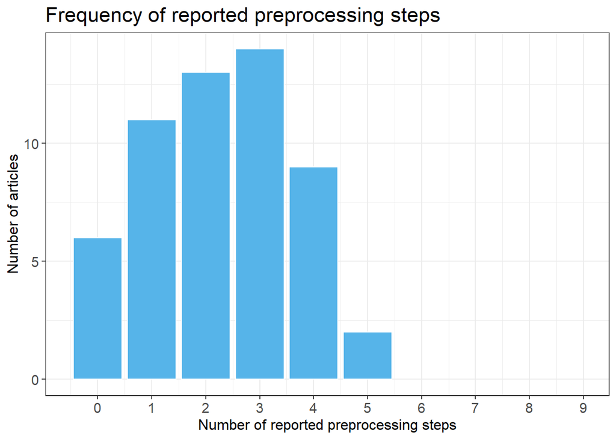

```r
My_Theme = theme(
    text = element_text(size = 14),
    axis.title.x = element_text(size = 12),
    axis.title.y = element_text(size = 12)
)
# 1: Frequency of reported preprocessing steps
dat_pipe %>%
    ggplot(aes(x = prep_sum, y = stat(count))) +
    geom_bar(color = "white", fill = "#56B4E9") +
    theme_bw()+
    # xlim(0, 9) +
    scale_x_continuous(breaks = c(0, 1, 2, 3, 4, 5, 6, 7, 8, 9), limits = c(-0.5, 9)) +
    labs(title = "Frequency of reported preprocessing steps",
         y = "Number of articles",
         x = "Number of reported preprocessing steps") +
    My_Theme
```

```r
psych::describe(dat_pipe$prep_sum)
```

```
##    vars  n mean   sd median trimmed  mad min max range  skew kurtosis   se
## X1    1 55 2.27 1.35      2    2.29 1.48   0   5     5 -0.01    -0.92 0.18
```

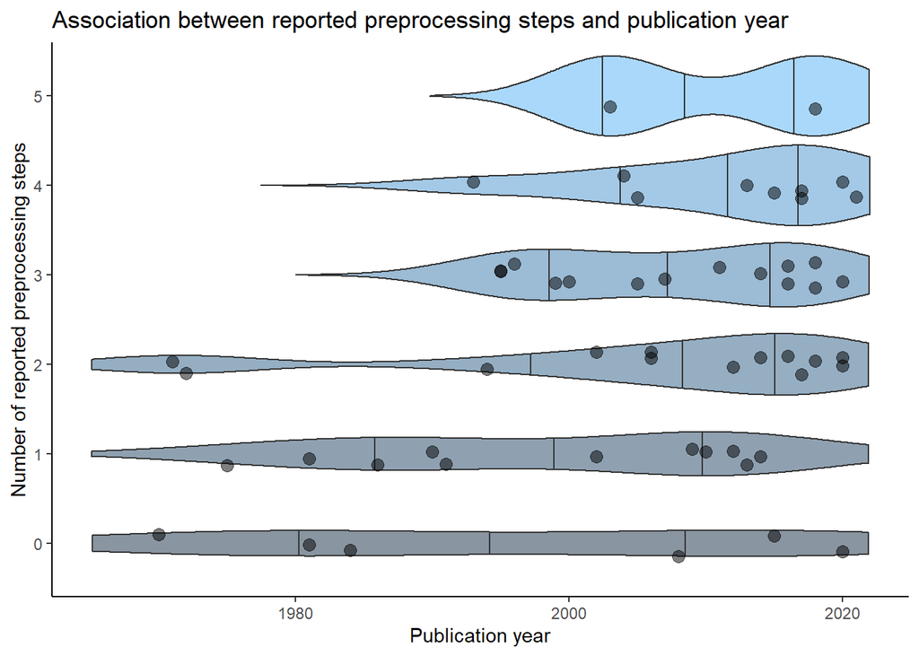

```r
# Change in number of reported steps by year
dat_pipe$Year <- as.numeric(dat_pipe$Year)

dat_pipe %>%
    ggplot(aes(x = as.character(prep_sum), y = Year, fill=prep_sum)) +
    geom_violin(
        trim = FALSE,
        draw_quantiles = c(0.25, 0.5, 0.75),
        alpha = 0.5
    ) +
    geom_jitter(
        width = 0.15, # points spread out over 15% of available width
        height = 0, # do not move position on the y-axis
        alpha = 0.5,
        size = 3
    ) +
    ylim(1965, 2022) +
    labs(title = "Association between reported preprocessing steps and publication year",
         y = "Publication year",
         x = "Number of reported preprocessing steps") +
    theme_classic() +
    theme(legend.position = "none") +
    coord_flip() +
    theme(panel.grid.major = element_blank(),panel.grid.minor = element_blank())
```

```r
# Order of preprocessing steps reported
dat_pipe %>%
    count(order_sum)
```

```
##   order_sum  n
## 1         1  5
## 2        NA 50
```

```r
# Articles reporting the number of excluded observations in the last 5 years
dat_5years <- dat_pipe %>%
    subset(Year >=2017) # 13 observations
dat_5years$outlier_sum
```

```
##  [1] NA  1  1 NA  1  1 NA  1  1 NA NA NA NA
```

```r
# Articles reporting order of preprocessing steps
dat_order <- dat_pipe %>%
    subset(order_sum == "1")
dat_order$Year
```

```
## [1] 2018 2017 2020 2005 1995
```

#### Estimating the Simon effect

```r
dat_ag <- aggregate(cbind(Mean1, SD1, Mean2, SD2) ~ Article, dat_all, mean)
dat_ag
```

```
##             Article    Mean1      SD1    Mean2     SD2
## 1      W\xfchr_2018  419.500   9.9250  448.500   9.825
## 2    Aisenberg_2012  415.665  59.3150  455.945  55.795
## 3          Cho_2011  457.875  64.2625  475.000  68.560
## 4        Craft_1970  438.500  78.4000  486.000  81.200
## 5    Davranche_2020  350.000  37.9500  374.000  44.270
## 6      Heister_1994  310.000  33.5000  370.500  46.500
## 7     Hietanen_1995  592.000  64.0000  684.000 100.000
## 8        Jones_2016  458.000  82.0000  486.000  94.000
## 9  Kalanthroff_2020  555.000  96.0000  606.000  96.000
## 10       Kotov_2017 1591.500 243.2500 1579.250 238.500
## 11      Masaki_2000  307.450  50.4400  426.970  51.510
## 12    McIntosh_2017  459.980  98.5700  478.040  82.890
## 13    Peterson_2002  424.210  39.9000  657.340  79.200
## 14       Ragot_1981  429.000  34.0000  457.000  32.000
## 15       Ragot_1984  431.000  32.0000  457.500  29.500
## 16       Ragot_1986  466.750  66.7500  497.750  66.750
## 17    Schnabel_2021  624.000  27.0000  633.000  26.000
## 18   Schneider_2020  483.500  73.5850  520.000  77.460
## 19       Simon_1981  718.500 138.5000  807.000 158.500
## 20      Stocco_2017  421.000  73.0000  489.000  88.000
## 21     VanVeen_2008  506.500 110.0000  554.500 110.000
## 22       Zhang_2004  621.900  77.8270  621.500  72.085
## 23       Zwaan_2018  427.500  80.4950  462.250  80.050
```

##### Estimate of Simon effect: Random effects three-level meta-analysis (study/effect size per result reported):

28 articles with 60 observations can be included. The estimate of our pooled Simon effect is d = .86 (.55 - 1.17). However, the test for heterogeneity, Q(59) = 384.77, p < .001, indicates that there are true effect size differences in the data.

```r
meta_model <- metafor::rma.mv(yi = es, V = es_var, slab = Article, data = dat_all, random = ~ 1 | Article/Article_exp_group_cond, test = "t", method = "REML")
summary(meta_model)
```

```
##
## Multivariate Meta-Analysis Model (k = 60; method: REML)
##
##   logLik  Deviance       AIC       BIC      AICc
## -59.6113  119.2227  125.2227  131.4553  125.6590
##
## Variance Components:
##
##             estim    sqrt  nlvls  fixed                          factor
## sigma^2.1  0.5419  0.7362     28     no                         Article
## sigma^2.2  0.0396  0.1990     60     no  Article/Article_exp_group_cond
##
## Test for Heterogeneity:
## Q(df = 59) = 384.7711, p-val < .0001
##
## Model Results:
##
## estimate      se    tval  df    pval   ci.lb   ci.ub
##   0.8589  0.1543  5.5671  59  <.0001  0.5502  1.1677  ***
##
## ---
## Signif. codes:  0 '***' 0.001 '**' 0.01 '*' 0.05 '.' 0.1 ' ' 1
```

```r
# sigma^2.1 = random effects variance for between article variance (between-study heterogeneity variance)
# sigma^2.2 = random effects variance within articles
```